## Statistical Inference Course Project 2: Basic Inferential Data Analysis

Author: E. Mineo Date: October 7, 2018

In this second project of the course, the R built-in ToothGrowth dataset is used to perform a basic statistical inference exercise.

1. Exploratory Analysis

```r
library(datasets)
library(ggplot2)
d <- ToothGrowth
```

```r
str(d)
```

```
## 'data.frame':    60 obs. of  3 variables:
##  $ len : num  4.2 11.5 7.3 5.8 6.4 10 11.2 11.2 5.2 7 ...
##  $ supp: Factor w/ 2 levels "OJ","VC": 2 2 2 2 2 2 2 2 2 2 ...
##  $ dose: num  0.5 0.5 0.5 0.5 0.5 0.5 0.5 0.5 0.5 0.5 ...
```

```r
summary(d)
```

```
##       len        supp         dose
##  Min.   : 4.20   OJ:30   Min.   :0.500
##  1st Qu.:13.07   VC:30   1st Qu.:0.500
##  Median :19.25           Median :1.000
##  Mean   :18.81           Mean   :1.167
##  3rd Qu.:25.27           3rd Qu.:2.000
##  Max.   :33.90           Max.   :2.000
```

The dataset contains 60 observations and 3 variables: len, supp and dose. Supp is a factor with two levels “OJ”, orange juice and “VC”, vitamin C. There are 3 doses: 0.5, 1 and 2mg/day. Len is the response variable. The dataset is plotted in figure 1. The tooth length seems to be different depending on dose and supplement type. Let’s verify this using a T-test.

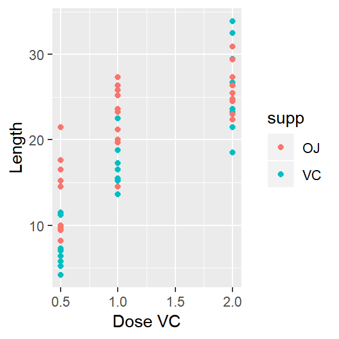

```r
qplot(dose,len,data=d,ylab = "Length",xlab="Dose VC",color=supp)
```

Fig.1: Plot of the ToothGrowth dataset

2.Comparison of supplement and dose

1. Comparison of supplement

```r
g1 <- d[d$supp=="VC",] #Group of animal that received vitamin C
g2 <- d[d$supp=="OJ",] #Group of animal that received orange juice
```

T-Confidence Interval Method

```r
n1 <- length(g1$len)
n2 <- length(g2$len)
sp <- sqrt(((n1-1) * sd(g1$len)^2 + (n2-1) * sd(g2$len)^2) / (n1 + n2 - 2))
md <- mean(g2$len) - mean(g1$len)#mean difference
semd <- sp * sqrt(1 / n1 + 1/n2)#standard error of the mean difference
md + c(-1, 1) * qt(.975, n1 + n2 - 2) * semd #T-CI
```

```
## [1] -0.1670064  7.5670064
```

T-test Method

```r
t.test(g2$len, g1$len, paired = FALSE)
```

```
##
##  Welch Two Sample t-test
##
## data:  g2$len and g1$len
## t = 1.9153, df = 55.309, p-value = 0.06063
## alternative hypothesis: true difference in means is not equal to 0
## 95 percent confidence interval:
##  -0.1710156  7.5710156
## sample estimates:
## mean of x mean of y
##  20.66333  16.96333
```

Conclusion: The confidence interval and the p-value show that H0 cannot be rejected with alpha=5%. This means that there is no evidence that the supplement type has an effect on the tooth length.

2. Comparison of doses

Test 1: 0.5 vs. 1 mg/day

```r
g3 <- d[d$dose=="0.5",]$len #Group of animals that received 0.5 mg/day
g4 <- d[d$dose=="1",]$len #Group of animals that received 1 mg/day
t.test(g4, g3, paired = FALSE)
```

```
##
##  Welch Two Sample t-test
##
## data:  g4 and g3
## t = 6.4766, df = 37.986, p-value = 1.268e-07
## alternative hypothesis: true difference in means is not equal to 0
## 95 percent confidence interval:
##   6.276219 11.983781
## sample estimates:
## mean of x mean of y
##    19.735    10.605
```

Conclusion test 1: Hypothesis H0 rejected, there is a significant difference between the effect of the two doses. On average, the length of odontoblasts with a dose of 1 mg/day is greater than with a dose of 0.5 mg/day.

Test 2: 0.5 vs 2 mg/day

```r
g5 <- d[d$dose=="2",]$len #Group of animals that received 2 mg/day
t.test(g5, g3, paired = FALSE)
```

```
##
##  Welch Two Sample t-test
##
## data:  g5 and g3
## t = 11.799, df = 36.883, p-value = 4.398e-14
## alternative hypothesis: true difference in means is not equal to 0
## 95 percent confidence interval:
##  12.83383 18.15617
## sample estimates:
## mean of x mean of y
##    26.100    10.605
```

Conclusion test 2: Hypothesis H0 rejected, the difference between the effect of the two doses is strongly signififcant (p-value = 4.398e-14). On average, the length of odontoblasts with a dose of 2 mg/day is greater than with a dose of 0.5 mg/day.

Test 3: 1 vs 2 mg/day

```r
t.test(g5, g4, paired = FALSE)
```

```
##
##  Welch Two Sample t-test
##
## data:  g5 and g4
## t = 4.9005, df = 37.101, p-value = 1.906e-05
## alternative hypothesis: true difference in means is not equal to 0
## 95 percent confidence interval:
##  3.733519 8.996481
## sample estimates:
## mean of x mean of y
##    26.100    19.735
```

Conclusion test 3: Hypothesis H0 rejected, there is a significant difference between the effect of the two doses. On average, the length of odontoblasts with a dose of 2 mg/day is greater than with a dose of 1mg/day.